# Spatial Correlation Analytics Between Population and COVID-19 Confirmed Cases in New York State

## Author: Weiye Chen & Shaohua Wang, University of Illinois at Urbana-Champaign

This Jupyter notebook demonstrates spatial correlation analysis between population and CVOID-19 confirmed cases in New York State.

We are taking the state of New York as our study area. This notebook uses geospatial libraries to show the spatial distribution of population data, COVID-19 confirmed cases, daily increases during the past week in the New York State, and demonstrate results for the spatial correlation analytics between population and the number of confirmed COVID-19 cases in New York State.

# Notebook Outline

- Data preparing
  - Setup
  - Population Data
  - COVID-19 Data
- Spatial Analysis
  - Spatial distrinution
  - Spatio-temporal visualization
  - Spatial Correlation Analytics

## Data Preparation

The first part is a demostration that shows users how to prepare population data and COVID-19 data in New York State.

### Set up the environment by importing libraries

This notebook depends on numpy, pandas, geopandas, shapely, and other libraries available in CyberGISX-Jupyter. In order to set up an environment to store and manipulate the Population data, we need to import these libraries.

```python
import pathlib
import os
import tarfile

import requests
import shutil
import zipfile

import pandas as pd
import pathlib
import os
import tarfile

import requests
import shutil
import zipfile

# Plotting the population data
import matplotlib.pyplot as plt
import datetime
%matplotlib inline

import numpy as np
import geopandas as gpd
from shapely.geometry import Point

import plotly.figure_factory as ff
import plotly.express as px
import json
import plotly.graph_objects as go
import cufflinks as cf

import seaborn as sns

import warnings
warnings.filterwarnings("ignore")
```

### Population data

Population data for New York State

This piece of data is formatted as a shapefile. link: https://www.arcgis.com/home/item.html?id=3b69769aa9b646a483af81d05e7702d2

U.S. Counties represents the counties of the United States in the 50 states, the District of Columbia, and Puerto Rico.

Originally extracted from this layer package: http://www.arcgis.com/home/item.html?id=a00d6b6149b34ed3b833e10fb72ef47b

```python
%%time
file = pathlib.Path("USA_Counties_as_Shape.zip")
if file.exists ():
    print ("Population data exist")
else:
    print ("Population data not exist, Downloading the Population data...")
    !wget https://s3-eu-west-1.amazonaws.com/pfigshare-u-files/22153815/USA_Counties_as_Shape.zip
```

```
Population data exist
CPU times: user 334 µs, sys: 234 µs, total: 568 µs
Wall time: 430 µs
```

Show the first five records of the new york state in this shapfile.

```python
%%time
pop = gpd.read_file("zip://USA_Counties_as_Shape.zip")
pop = pop[pop.STATE_NAME=='New York']
pop
```

```
CPU times: user 3.71 s, sys: 190 ms, total: 3.9 s
Wall time: 3.91 s
```

|  | NAME | STATE_NAME | STATE_FIPS | CNTY_FIPS | FIPS | POP2010 | POP10_SQMI | POP2012 | POP12_SQMI | WHITE | ... | OWNER_OCC | RENTER_OCC | NO_FARMS07 | AVG_SIZE07 | CROP_ACR07 | AVG_SALE07 | SQMI | Shape_Leng | Shape_Area | geometry |
| --- | --- | --- | --- | --- | --- | --- | --- | --- | --- | --- | --- | --- | --- | --- | --- | --- | --- | --- | --- | --- | --- |
| 1828 | Albany | New York | 36 | 001 | 36001 | 304204 | 570.6 | 305432 | 572.871183 | 237873 | ... | 72577 | 53674 | 498.0 | 123.0 | 32020.0 | 45.01 | 533.16 | 1.787027 | 0.151470 | MULTIPOLYGON (((-73.87971 42.76647, -73.87986 ... |
| 1829 | Allegany | New York | 36 | 003 | 36003 | 48946 | 47.3 | 49415 | 47.771655 | 47085 | ... | 13563 | 4645 | 847.0 | 178.0 | 74635.0 | 54.39 | 1034.40 | 2.197075 | 0.292292 | POLYGON ((-78.22079 42.52173, -78.21983 42.521... |
| 1830 | Bronx | New York | 36 | 005 | 36005 | 1385108 | 32939.5 | 1397295 | 33229.369798 | 386497 | ... | 93101 | 390348 | 1.0 | -99.0 | 0.0 | -99.00 | 42.05 | 1.289333 | 0.011631 | MULTIPOLYGON (((-73.89687 40.79565, -73.89703 ... |
| 1831 | Broome | New York | 36 | 007 | 36007 | 200600 | 280.3 | 200701 | 280.461425 | 176444 | ... | 53260 | 28907 | 580.0 | 149.0 | 43575.0 | 51.53 | 715.61 | 2.473984 | 0.201904 | POLYGON ((-75.86342 42.40935, -75.86251 42.399... |
| 1832 | Cattaraugus | New York | 36 | 009 | 36009 | 80317 | 60.7 | 80840 | 61.126654 | 74639 | ... | 23306 | 8957 | 1122.0 | 163.0 | 91562.0 | 66.98 | 1322.50 | 2.867147 | 0.373649 | POLYGON ((-79.02148 42.53803, -79.01788 42.536... |
| ... | ... | ... | ... | ... | ... | ... | ... | ... | ... | ... | ... | ... | ... | ... | ... | ... | ... | ... | ... | ... | ... |
| 1885 | Washington | New York | 36 | 115 | 36115 | 63216 | 74.7 | 63763 | 75.353053 | 59815 | ... | 17722 | 6420 | 843.0 | 241.0 | 112016.0 | 133.17 | 846.19 | 3.037408 | 0.243164 | POLYGON ((-73.37456 43.79744, -73.37352 43.796... |
| 1886 | Wayne | New York | 36 | 117 | 36117 | 93772 | 154.8 | 94142 | 155.362654 | 87148 | ... | 28106 | 8479 | 938.0 | 180.0 | 119662.0 | 180.13 | 605.95 | 2.669413 | 0.173682 | MULTIPOLYGON (((-76.94668 43.25894, -76.94638 ... |
| 1887 | Westchester | New York | 36 | 119 | 36119 | 949113 | 2111.6 | 949931 | 2113.399929 | 646471 | ... | 213888 | 133344 | 106.0 | 80.0 | 2512.0 | 103.75 | 449.48 | 2.908143 | 0.124902 | MULTIPOLYGON (((-73.76548 40.87745, -73.76569 ... |
| 1888 | Wyoming | New York | 36 | 121 | 36121 | 42155 | 70.7 | 42520 | 71.319546 | 38602 | ... | 11762 | 3739 | 761.0 | 287.0 | 157338.0 | 302.16 | 596.19 | 1.900056 | 0.169651 | POLYGON ((-78.17165 42.87038, -78.16345 42.870... |
| 1889 | Yates | New York | 36 | 123 | 36123 | 25348 | 67.4 | 25464 | 67.754038 | 24647 | ... | 7193 | 2324 | 864.0 | 146.0 | 86596.0 | 102.29 | 375.83 | 1.511735 | 0.106828 | POLYGON ((-76.94756 42.76441, -76.94773 42.759... |

62 rows × 56 columns

### COVID-19 Data

The data is retrieved from [Johns Hopkins CSSE COVID-19 cases dataset repository](https://github.com/CSSEGISandData/COVID-19/).

The data format is CSV file.

```python
%%time
confirmed_cases = pd.read_csv(
    "https://github.com/CSSEGISandData/COVID-19/raw/master/csse_covid_19_data/csse_covid_19_time_series/time_series_covid19_confirmed_US.csv"
)
confirmed_cases = confirmed_cases[confirmed_cases['Province_State'] == 'New York']
confirmed_cases
#confirmed_cases.head(5)
```

```
CPU times: user 59.8 ms, sys: 17.5 ms, total: 77.3 ms
Wall time: 449 ms
```

|  | UID | iso2 | iso3 | code3 | FIPS | Admin2 | Province_State | Country_Region | Lat | Long_ | ... | 3/21/2020 | 3/22/2020 | 3/23/2020 | 3/24/2020 | 3/25/2020 | 3/26/2020 | 3/27/2020 | 3/28/2020 | 3/29/2020 | 3/30/2020 |
| --- | --- | --- | --- | --- | --- | --- | --- | --- | --- | --- | --- | --- | --- | --- | --- | --- | --- | --- | --- | --- | --- |
| 1833 | 84036001 | US | USA | 840 | 36001.0 | Albany | New York | US | 42.600603 | -73.977239 | ... | 88 | 123 | 127 | 146 | 152 | 171 | 187 | 195 | 205 | 217 |
| 1834 | 84036003 | US | USA | 840 | 36003.0 | Allegany | New York | US | 42.257484 | -78.027505 | ... | 2 | 2 | 2 | 2 | 2 | 2 | 2 | 2 | 6 | 7 |
| 1835 | 84036005 | US | USA | 840 | 36005.0 | Bronx | New York | US | 40.852093 | -73.862828 | ... | 0 | 0 | 0 | 0 | 0 | 0 | 0 | 0 | 0 | 0 |
| 1836 | 84036007 | US | USA | 840 | 36007.0 | Broome | New York | US | 42.159032 | -75.813261 | ... | 2 | 3 | 3 | 9 | 11 | 16 | 18 | 23 | 29 | 35 |
| 1837 | 84036009 | US | USA | 840 | 36009.0 | Cattaraugus | New York | US | 42.247782 | -78.679231 | ... | 0 | 0 | 0 | 0 | 0 | 0 | 0 | 1 | 4 | 6 |
| ... | ... | ... | ... | ... | ... | ... | ... | ... | ... | ... | ... | ... | ... | ... | ... | ... | ... | ... | ... | ... | ... |
| 1892 | 84036119 | US | USA | 840 | 36119.0 | Westchester | New York | US | 41.162784 | -73.757417 | ... | 1387 | 1873 | 2894 | 3891 | 4691 | 5944 | 7187 | 7875 | 8519 | 9326 |
| 1893 | 84036121 | US | USA | 840 | 36121.0 | Wyoming | New York | US | 42.701451 | -78.221996 | ... | 2 | 2 | 2 | 4 | 4 | 7 | 7 | 7 | 8 | 8 |
| 1894 | 84036123 | US | USA | 840 | 36123.0 | Yates | New York | US | 42.635055 | -77.103699 | ... | 0 | 0 | 0 | 0 | 0 | 0 | 0 | 0 | 0 | 0 |
| 3181 | 84080036 | US | USA | 840 | 80036.0 | Out of NY | New York | US | 0.000000 | 0.000000 | ... | 0 | 0 | 0 | 0 | 0 | 0 | 0 | 0 | 0 | 0 |
| 3233 | 84090036 | US | USA | 840 | 90036.0 | Unassigned | New York | US | 0.000000 | 0.000000 | ... | 0 | 23 | 107 | 0 | 0 | 0 | 0 | 0 | 0 | 0 |

64 rows × 80 columns

Show the time series data

```python
columns = confirmed_cases.columns
dates = columns[11:-1]
dates
```

```
Index(['1/22/2020', '1/23/2020', '1/24/2020', '1/25/2020', '1/26/2020',
       '1/27/2020', '1/28/2020', '1/29/2020', '1/30/2020', '1/31/2020',
       '2/1/2020', '2/2/2020', '2/3/2020', '2/4/2020', '2/5/2020', '2/6/2020',
       '2/7/2020', '2/8/2020', '2/9/2020', '2/10/2020', '2/11/2020',
       '2/12/2020', '2/13/2020', '2/14/2020', '2/15/2020', '2/16/2020',
       '2/17/2020', '2/18/2020', '2/19/2020', '2/20/2020', '2/21/2020',
       '2/22/2020', '2/23/2020', '2/24/2020', '2/25/2020', '2/26/2020',
       '2/27/2020', '2/28/2020', '2/29/2020', '3/1/2020', '3/2/2020',
       '3/3/2020', '3/4/2020', '3/5/2020', '3/6/2020', '3/7/2020', '3/8/2020',
       '3/9/2020', '3/10/2020', '3/11/2020', '3/12/2020', '3/13/2020',
       '3/14/2020', '3/15/2020', '3/16/2020', '3/17/2020', '3/18/2020',
       '3/19/2020', '3/20/2020', '3/21/2020', '3/22/2020', '3/23/2020',
       '3/24/2020', '3/25/2020', '3/26/2020', '3/27/2020', '3/28/2020',
       '3/29/2020'],
      dtype='object')
```

```python
pop["Admin2"]=pop["NAME"]
pop.shape
```

```
(62, 57)
```

```python
pop.describe()
```

|  | POP2010 | POP10_SQMI | POP2012 | POP12_SQMI | WHITE | BLACK | AMERI_ES | ASIAN | HAWN_PI | HISPANIC | ... | VACANT | OWNER_OCC | RENTER_OCC | NO_FARMS07 | AVG_SIZE07 | CROP_ACR07 | AVG_SALE07 | SQMI | Shape_Leng | Shape_Area |
| --- | --- | --- | --- | --- | --- | --- | --- | --- | --- | --- | --- | --- | --- | --- | --- | --- | --- | --- | --- | --- | --- |
| count | 6.200000e+01 | 62.000000 | 6.200000e+01 | 62.000000 | 6.200000e+01 | 62.000000 | 62.000000 | 62.000000 | 62.000000 | 62.000000 | ... | 62.000000 | 62.000000 | 62.000000 | 62.000000 | 62.000000 | 62.000000 | 62.000000 | 62.000000 | 62.000000 | 62.000000 |
| mean | 3.125500e+05 | 3015.661290 | 3.150453e+05 | 3046.961245 | 2.054996e+05 | 49577.419355 | 1724.290323 | 22907.161290 | 141.387097 | 55111.645161 | ... | 12747.548387 | 62868.338710 | 55159.967742 | 586.322581 | 157.387097 | 69594.919355 | 107.102097 | 783.529355 | 2.801870 | 0.223882 |
| std | 5.323563e+05 | 10840.494722 | 5.379665e+05 | 10959.168351 | 2.829881e+05 | 139015.384817 | 3601.447083 | 75989.530459 | 311.764537 | 146525.909445 | ... | 17493.169368 | 89108.349004 | 130407.707749 | 377.733785 | 101.719859 | 54875.206378 | 98.465447 | 510.676050 | 2.388439 | 0.148468 |
| min | 4.836000e+03 | 2.700000 | 4.822000e+03 | 2.667448 | 4.705000e+03 | 35.000000 | 11.000000 | 24.000000 | 2.000000 | 51.000000 | ... | 1853.000000 | 1826.000000 | 436.000000 | 0.000000 | -99.000000 | 0.000000 | -99.000000 | 22.790000 | 0.961021 | 0.006296 |
| 25% | 5.124350e+04 | 70.550000 | 5.162950e+04 | 71.293766 | 4.906100e+04 | 1061.500000 | 138.750000 | 367.500000 | 12.250000 | 1323.250000 | ... | 4282.000000 | 15441.500000 | 6369.750000 | 335.500000 | 123.750000 | 25046.000000 | 58.330000 | 459.987500 | 1.865630 | 0.128504 |
| 50% | 9.130100e+04 | 115.750000 | 9.166000e+04 | 116.497116 | 8.135600e+04 | 2871.000000 | 357.000000 | 950.000000 | 22.000000 | 2503.000000 | ... | 7127.500000 | 23658.500000 | 9969.000000 | 587.500000 | 176.500000 | 65498.000000 | 94.910000 | 663.910000 | 2.457530 | 0.189159 |
| 75% | 2.310602e+05 | 409.725000 | 2.333172e+05 | 412.029970 | 2.065555e+05 | 14815.750000 | 1079.000000 | 8319.000000 | 103.250000 | 14103.000000 | ... | 11281.000000 | 63807.750000 | 30053.750000 | 830.250000 | 220.750000 | 106100.000000 | 132.610000 | 1029.810000 | 2.897894 | 0.292240 |
| max | 2.504700e+06 | 69586.400000 | 2.549696e+06 | 70267.792892 | 1.206297e+06 | 860083.000000 | 18260.000000 | 511787.000000 | 1530.000000 | 741413.000000 | ... | 83437.000000 | 393507.000000 | 662615.000000 | 1658.000000 | 333.000000 | 211164.000000 | 415.270000 | 2804.820000 | 18.351044 | 0.821949 |

8 rows × 50 columns

```python
confirmed_cases = confirmed_cases[confirmed_cases['Admin2'] != 'Unassigned']
```

```python
confirmed_cases.head(64)
```

|  | UID | iso2 | iso3 | code3 | FIPS | Admin2 | Province_State | Country_Region | Lat | Long_ | ... | 3/21/2020 | 3/22/2020 | 3/23/2020 | 3/24/2020 | 3/25/2020 | 3/26/2020 | 3/27/2020 | 3/28/2020 | 3/29/2020 | 3/30/2020 |
| --- | --- | --- | --- | --- | --- | --- | --- | --- | --- | --- | --- | --- | --- | --- | --- | --- | --- | --- | --- | --- | --- |
| 1833 | 84036001 | US | USA | 840 | 36001.0 | Albany | New York | US | 42.600603 | -73.977239 | ... | 88 | 123 | 127 | 146 | 152 | 171 | 187 | 195 | 205 | 217 |
| 1834 | 84036003 | US | USA | 840 | 36003.0 | Allegany | New York | US | 42.257484 | -78.027505 | ... | 2 | 2 | 2 | 2 | 2 | 2 | 2 | 2 | 6 | 7 |
| 1835 | 84036005 | US | USA | 840 | 36005.0 | Bronx | New York | US | 40.852093 | -73.862828 | ... | 0 | 0 | 0 | 0 | 0 | 0 | 0 | 0 | 0 | 0 |
| 1836 | 84036007 | US | USA | 840 | 36007.0 | Broome | New York | US | 42.159032 | -75.813261 | ... | 2 | 3 | 3 | 9 | 11 | 16 | 18 | 23 | 29 | 35 |
| 1837 | 84036009 | US | USA | 840 | 36009.0 | Cattaraugus | New York | US | 42.247782 | -78.679231 | ... | 0 | 0 | 0 | 0 | 0 | 0 | 0 | 1 | 4 | 6 |
| ... | ... | ... | ... | ... | ... | ... | ... | ... | ... | ... | ... | ... | ... | ... | ... | ... | ... | ... | ... | ... | ... |
| 1891 | 84036117 | US | USA | 840 | 36117.0 | Wayne | New York | US | 43.154944 | -77.029765 | ... | 3 | 3 | 3 | 6 | 7 | 8 | 11 | 12 | 12 | 15 |
| 1892 | 84036119 | US | USA | 840 | 36119.0 | Westchester | New York | US | 41.162784 | -73.757417 | ... | 1387 | 1873 | 2894 | 3891 | 4691 | 5944 | 7187 | 7875 | 8519 | 9326 |
| 1893 | 84036121 | US | USA | 840 | 36121.0 | Wyoming | New York | US | 42.701451 | -78.221996 | ... | 2 | 2 | 2 | 4 | 4 | 7 | 7 | 7 | 8 | 8 |
| 1894 | 84036123 | US | USA | 840 | 36123.0 | Yates | New York | US | 42.635055 | -77.103699 | ... | 0 | 0 | 0 | 0 | 0 | 0 | 0 | 0 | 0 | 0 |
| 3181 | 84080036 | US | USA | 840 | 80036.0 | Out of NY | New York | US | 0.000000 | 0.000000 | ... | 0 | 0 | 0 | 0 | 0 | 0 | 0 | 0 | 0 | 0 |

63 rows × 80 columns

## Spatial Analysis

This part is a demostration that shows spatial correlation analytics bwtween population and CVOID-19 confirmed cases in New York State.

### Spatial distribution

```python
from urllib.request import urlopen
import json
#with urlopen('https://raw.githubusercontent.com/cybergis/COVID_19/master/counties_update_new.geojson') as response:
with urlopen('https://raw.githubusercontent.com/plotly/datasets/master/geojson-counties-fips.json') as response:
    counties = json.load(response)
```

Show the spatial distribution of the COVID-19 Confirmed Cases in New York State using Mapbox Choropleth maps with Plotly. It will take 5 seconds to show the interactive map.

```python
%%time
fig = go.Figure(
    go.Choroplethmapbox(
        geojson=counties, locations=confirmed_cases.FIPS,
        z=np.log1p(confirmed_cases['3/29/2020']),
#         z=confirmed_cases['3/29/20'],
        colorscale="reds", marker_opacity=0.5, marker_line_width=0,
        ids = confirmed_cases['Admin2'],
        name = 'Confirmed Cases',
        colorbar_thickness = 10,
        hoverinfo = 'text',
        text = confirmed_cases['Admin2'] + ', ' + confirmed_cases['Province_State'] + '\n' + confirmed_cases['3/29/2020'].astype('str'),
#         showlegend = True,
        showscale = True,
        colorbar = dict(
            title = "# confirmed cases",
            titleside = 'top',
            tickmode = 'array',
            tickvals = np.arange(11),
            ticktext = np.round(np.exp(np.arange(0,11)) - 1),
            ticks = 'inside',
            outlinewidth = 0
        )
    ))
fig.update_layout(mapbox_style="carto-positron",
                  mapbox_zoom=5, #mapbox_center = {"lat": 37.0902, "lon": -95.7129},)
                  mapbox_center={"lat": 42.7, "lon": -76},
                 )
fig.update_layout(margin={"r":10,"t":10,"l":10,"b":10})

fig.show()
```

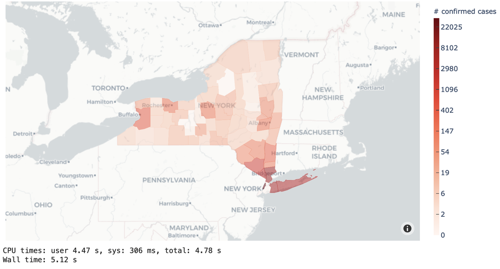

The density map is shown for the COVID-19 Confirmed Cases in New York State using Mapbox Density maps with Plotly. It will take about 200 milliseconds to show the interactive map.

```python
%%time
fig = go.Figure(
    go.Densitymapbox(
        name = 'Density of Confirmed Cases',
        opacity = 0.7,
        z = np.log1p(confirmed_cases['3/29/2020']),
        lat = confirmed_cases['Lat'],
        lon = confirmed_cases['Long_'],
        colorscale = 'reds',
        radius = 30,

        text = confirmed_cases['Admin2'] + ', ' + confirmed_cases['Province_State'] + '\n' + confirmed_cases['3/29/2020'].astype('str'),
        hoverinfo = 'text',
        colorbar = dict(
            title = "# confirmed cases",
            titleside = 'top',
            tickmode = 'array',
            tickvals = np.arange(11),
            ticktext = np.round(np.exp(np.arange(0,11)) - 1),
            ticks = 'inside',
            outlinewidth = 0
        )
    )
)
fig.update_layout(mapbox_style="carto-positron",
                  mapbox_zoom=5, #mapbox_center = {"lat": 37.0902, "lon": -95.7129},)
                  mapbox_center={"lat": 42.7, "lon": -76})
fig.update_layout(margin={"r":0.1,"t":0.1,"l":0.1,"b":0.1})

fig.show()
```

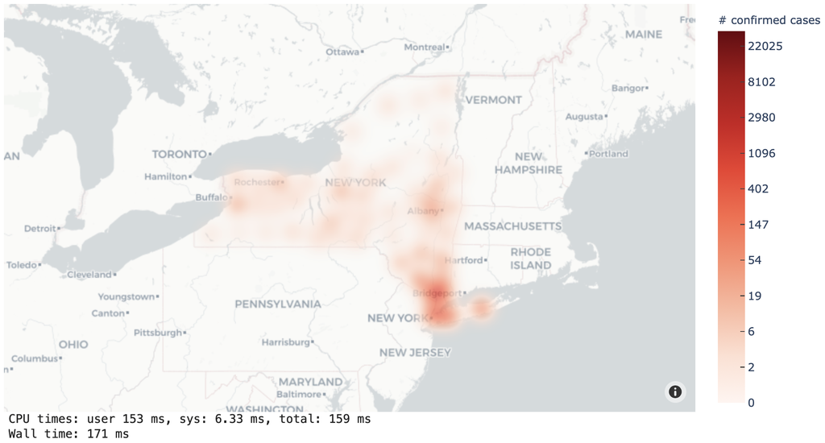

The trend in the number of COVID-19 confirmed cases in all counties in New York.

```python
nyc_count = confirmed_cases
nyc_count = nyc_count.set_index('Admin2')
nyc_count = nyc_count.T.iloc[11:]
```

Draw rectangles on the trace to zoom, and hover to see the data.

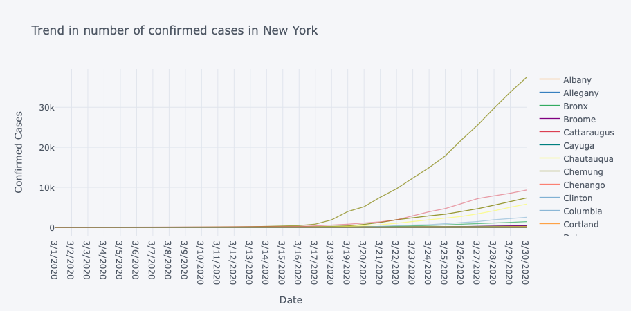

```python
nyc_count[-30:].iplot(asFigure=True, xTitle="Date", yTitle="Confirmed Cases",
                title = "Trend in number of confirmed cases in New York",
               )
```

Convert the y-axis to a logarithm scale.

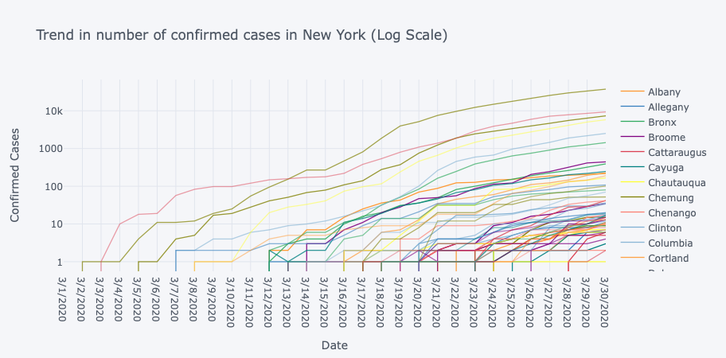

```python
nyc_count[-30:].iplot(asFigure=True, xTitle="Date", yTitle="Confirmed Cases",
                title = "Trend in number of confirmed cases in New York (Log Scale)",
                     logy = True
               )
```

### Spatio-temporal visualization

Number of confirmed cases during the Past Week in New York State. It will take 30 seconds to load the dynamic maps.

```python
%%time
fig = go.Figure()
dates_ = dates[-7:]
for date in dates_:
    fig.add_trace(
        dict(
            type="choroplethmapbox",
            visible = False,
            geojson=counties, locations=confirmed_cases.FIPS,
            z=np.log1p(confirmed_cases[date]),
            colorscale="reds", marker_opacity=0.5, marker_line_width=0,
            ids = confirmed_cases['Admin2'],
            name = 'Confirmed Cases',
            colorbar_thickness = 10,
            hoverinfo = 'text',
            text = confirmed_cases['Admin2'] + ', ' + confirmed_cases['Province_State'] + '\n' + confirmed_cases[date].astype('str'),
            showscale = True,
            zmin = 0,
            zmax = 11,
            colorbar = dict(
#                 title = "# confirmed cases",
                titleside = 'top',
                tickmode = 'array',
                tickvals = np.arange(11),
                ticktext = np.round(np.exp(np.arange(0,11)) - 1),
                ticks = 'inside',
                outlinewidth = 0,
                tickfont = {'color':'#a9a9a9'},
                x = 1
            )
        )
    )

steps = []
for i in range(len(fig.data)):
    step = dict(
        method='restyle',
        args=["visible", [False] * len(fig.data)],
        label = dates_[i],
    )
    step["args"][1][i] = True  # Toggle i'th trace to "visible"
    steps.append(step)

sliders = [dict(
    active=0,
    currentvalue={"prefix": "Date: "},
    pad={"t": 0, 'l' : 50, 'r':50},
    lenmode = 'fraction',
    len = 0.8,
    transition = {'easing': 'sin'},
    font = {'color':'#a9a9a9'},
    steps=steps,
)]

fig.update_layout(
    sliders=sliders
)

fig.data[0].visible = True

fig.update_layout(
    mapbox_style="carto-positron",
    mapbox_zoom=5, #mapbox_center = {"lat": 37.0902, "lon": -95.7129},)
    mapbox_center={"lat": 42.7, "lon": -76},
    margin={"r":10,"t":50,"l":15,"b":10},
    title={
        'text': "Confirmed Cases during the Past Week in the State of New York",
        'xref': "container"
    },
)
fig.show()
```

Drag on the slider to change date view. A preview to this visualization:

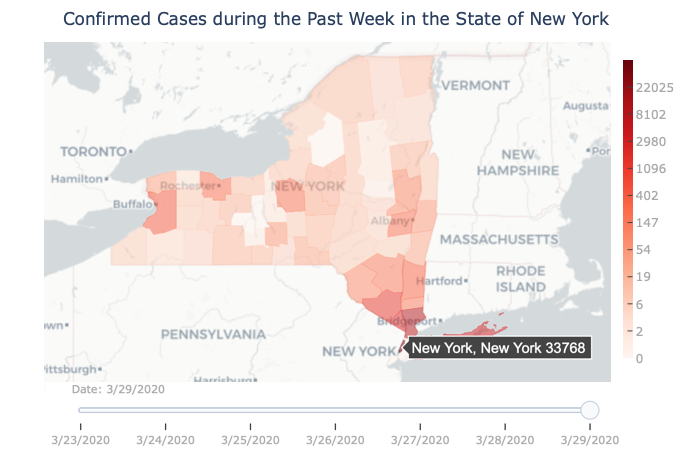

Daily increases during the Past Week in New York State. It will take 30 seconds to load the dynamic maps.

```python
%%time
import warnings
warnings.filterwarnings("ignore")
fig = go.Figure()
dates_ = dates[-8:]
for i in range(1,8):
    date = dates_[i]
    yesterday = dates_[i-1]
    fig.add_trace(
        dict(
            type="choroplethmapbox",
            visible = False,
            geojson=counties, locations=confirmed_cases.FIPS,
            z=np.log1p(confirmed_cases[date] - confirmed_cases[yesterday]),
            colorscale="reds", marker_opacity=0.5, marker_line_width=0,
            ids = confirmed_cases['Admin2'],
            name = 'Confirmed Cases',
            colorbar_thickness = 10,
            hoverinfo = 'text',
            text = confirmed_cases['Admin2'] + ', ' + confirmed_cases['Province_State'] + ' - Daily Increase: ' + (confirmed_cases[date] - confirmed_cases[yesterday]).astype('str'),
            showscale = True,
            zmin = 0,
            zmax = 8,
            colorbar = dict(
#                 title = "# confirmed cases",
                titleside = 'top',
                tickmode = 'array',
                tickvals = np.arange(0,9),
                ticktext = np.round(np.exp(np.arange(0,9)) - 1),
                ticks = 'inside',
                outlinewidth = 0,
                tickfont = {'color':'#a9a9a9'},
                x = 1
            )
        )
    )

steps = []
for i in range(len(fig.data)):
    step = dict(
        method='restyle',
        args=["visible", [False] * len(fig.data)],
        label = dates_[i+1],
    )
    step["args"][1][i] = True  # Toggle i'th trace to "visible"
    steps.append(step)

sliders = [dict(
    active=0,
    currentvalue={"prefix": "Date: "},
    pad={"t": 0, 'l' : 50, 'r':50},
    lenmode = 'fraction',
    len = 0.8,
    transition = {'easing': 'sin'},
    font = {'color':'#a9a9a9'},
    steps=steps,
)]

fig.update_layout(
    sliders=sliders
)

fig.data[0].visible = True

fig.update_layout(
    mapbox_style="carto-positron",
    mapbox_zoom=5, #mapbox_center = {"lat": 37.0902, "lon": -95.7129},)
    mapbox_center={"lat": 42.7, "lon": -76},
    margin={"r":10,"t":50,"l":15,"b":10},
    title={
        'text': "Daily Increases during the Past Week in the State of New York",
        'xref': "container"
    },
)

fig.show()
```

[output not shown]

### Spatial Correlation Analytics

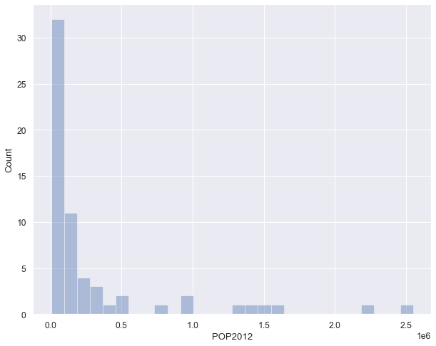

```python
sns.set(style='darkgrid', palette="deep", font_scale=1.1, rc={"figure.figsize": [10, 8]})
sns.distplot(pop['POP2012'], norm_hist=False, kde=False).set(xlabel='POP2012', ylabel='Count');
plt.savefig('POP2012_distplot.png')
```

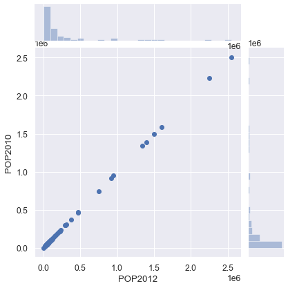

```python
sns.jointplot(x=pop['POP2012'], y=pop['POP2010']);
```

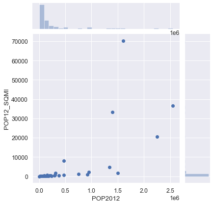

```python
sns.jointplot(x=pop['POP2012'], y=pop['POP12_SQMI']);
```

```python
%%time
merged_population = pop.merge(confirmed_cases, on=["Admin2"], how='outer')
merged_population.head()
```

```
CPU times: user 11.7 ms, sys: 1.48 ms, total: 13.2 ms
Wall time: 11.9 ms
```

|  | NAME | STATE_NAME | STATE_FIPS | CNTY_FIPS | FIPS_x | POP2010 | POP10_SQMI | POP2012 | POP12_SQMI | WHITE | ... | 3/21/2020 | 3/22/2020 | 3/23/2020 | 3/24/2020 | 3/25/2020 | 3/26/2020 | 3/27/2020 | 3/28/2020 | 3/29/2020 | 3/30/2020 |
| --- | --- | --- | --- | --- | --- | --- | --- | --- | --- | --- | --- | --- | --- | --- | --- | --- | --- | --- | --- | --- | --- |
| 0 | Albany | New York | 36 | 001 | 36001 | 304204.0 | 570.6 | 305432.0 | 572.871183 | 237873.0 | ... | 88 | 123 | 127 | 146 | 152 | 171 | 187 | 195 | 205 | 217 |
| 1 | Allegany | New York | 36 | 003 | 36003 | 48946.0 | 47.3 | 49415.0 | 47.771655 | 47085.0 | ... | 2 | 2 | 2 | 2 | 2 | 2 | 2 | 2 | 6 | 7 |
| 2 | Bronx | New York | 36 | 005 | 36005 | 1385108.0 | 32939.5 | 1397295.0 | 33229.369798 | 386497.0 | ... | 0 | 0 | 0 | 0 | 0 | 0 | 0 | 0 | 0 | 0 |
| 3 | Broome | New York | 36 | 007 | 36007 | 200600.0 | 280.3 | 200701.0 | 280.461425 | 176444.0 | ... | 2 | 3 | 3 | 9 | 11 | 16 | 18 | 23 | 29 | 35 |
| 4 | Cattaraugus | New York | 36 | 009 | 36009 | 80317.0 | 60.7 | 80840.0 | 61.126654 | 74639.0 | ... | 0 | 0 | 0 | 0 | 0 | 0 | 0 | 1 | 4 | 6 |

5 rows × 136 columns

Exploratory data analysis for population data and COVID-19 Confirmed Cases

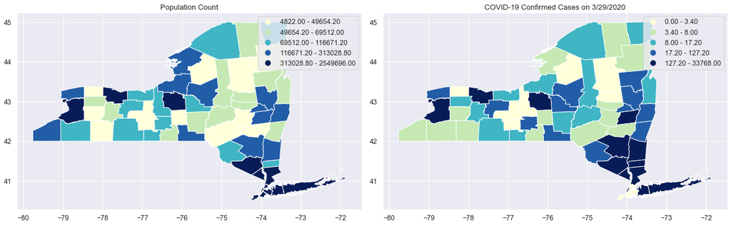

```
CPU times: user 3.21 s, sys: 258 ms, total: 3.47 s
Wall time: 3.92 s
```

```python
%%time
fig, ax = plt.subplots(1,2, figsize=(18,18))
merged_population.plot(column='POP2012', scheme='Quantiles', k=5, cmap='YlGnBu', legend=True, ax=ax[0]);
merged_population.plot(column='3/29/2020', scheme='Quantiles', k=5, cmap='YlGnBu', legend=True, ax=ax[1]);
plt.tight_layout()
ax[0].set_title("Population Count")
ax[1].set_title("COVID-19 Confirmed Cases on 3/29/2020")
plt.savefig('comparison.png', bbox_inches="tight")
plt.show()
```

### These two figures show that there is spatial correlation between the population and COVID-19 confirmed cases.

Compute the correlation matrix between the population dataset and the COVID-19 confirmed cases dataset and plot the heatmap

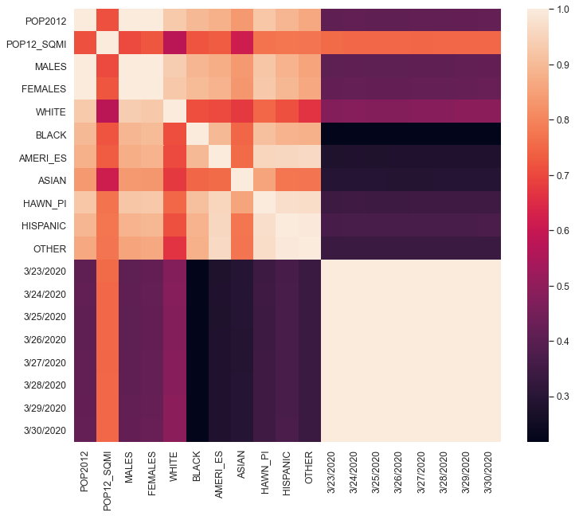

```
CPU times: user 343 ms, sys: 18.1 ms, total: 361 ms
Wall time: 359 ms
```

```python
%%time
columns = ['POP2012','POP12_SQMI','MALES','FEMALES','WHITE','BLACK','AMERI_ES','ASIAN','HAWN_PI','HISPANIC','OTHER','3/23/2020','3/24/2020','3/25/2020', '3/26/2020',
           '3/27/2020', '3/28/2020','3/29/2020','3/30/2020']

#
correlation = merged_population[columns].corr()

fig, ax = plt.subplots(figsize=(12,10))

sns.heatmap(correlation, xticklabels=columns,yticklabels=columns, ax=ax)

plt.show()
```

### The correlation matrix reveals the correlation between population density and the spatial distribution of the COVID-19 confirmed cases in New York State.